# Análisis de la población de Cali, Valle del Cauca: requerimientos promedio de energía diarios, información antropométrica y actividad física

Proyecto: Estimación del costo y asequibilidad a una dieta adecuada en la población urbana de Cali

9/21/2022

# Estructura poblacional y requerimientos de energía promedio en Cali, Valle del Cauca

## Requerimientos diarios de energía para niños y adolescentes

De conformidad con la resolución 003803 de 2016, los siguientes cuadros presentan los requerimientos diarios de energía para niños y adolescentes diferenciados según el sexo. Nótese que $AF ligera$ es una variable cualitativa tal que $AF ligera = 1$ si el requerimiento presupone una actividad física ligera, y $AF ligera = 0$ si presupone una actividad física moderada o vigorsa. Lo mismo valdría para $AF moderada$ y $AF vigorosa$.

### Requerimientos diarios de energía para niños y adolescentes de sexo masculino

Requerimientos diarios de energía para niños y adolescentes de sexo masculino (1-17 años)

| Límite inferior | Límite superior | Kcal/día | Kcal/kg/día | AF ligera | AF moderada | AF vigorosa |
| --- | --- | --- | --- | --- | --- | --- |
| 1 | 2 | 950 | 82 | 0 | 1 | 0 |
| 2 | 3 | 1125 | 84 | 0 | 1 | 0 |
| 3 | 4 | 1250 | 80 | 0 | 1 | 0 |
| 4 | 5 | 1350 | 77 | 0 | 1 | 0 |
| 5 | 6 | 1475 | 74 | 0 | 1 | 0 |
| 6 | 7 | 1575 | 73 | 0 | 1 | 0 |
| 7 | 8 | 1700 | 71 | 0 | 1 | 0 |
| 8 | 9 | 1825 | 69 | 0 | 1 | 0 |
| 9 | 10 | 1975 | 67 | 0 | 1 | 0 |
| 10 | 11 | 2150 | 65 | 0 | 1 | 0 |

### Requerimientos diarios de energía para niños y adolescentes de sexo femenino

Requerimientos diarios de energía para niñas y adolescentes de sexo femenino (1-17 años)

| Límite inferior | Límite superior | Kcal/día | Kcal/kg/día | AF ligera | AF moderada | AF vigorosa |
| --- | --- | --- | --- | --- | --- | --- |
| 1 | 2 | 850 | 80 | 0 | 1 | 0 |
| 2 | 3 | 1050 | 81 | 0 | 1 | 0 |
| 3 | 4 | 1150 | 77 | 0 | 1 | 0 |
| 4 | 5 | 1250 | 74 | 0 | 1 | 0 |
| 5 | 6 | 1325 | 72 | 0 | 1 | 0 |
| 6 | 7 | 1425 | 69 | 0 | 1 | 0 |
| 7 | 8 | 1550 | 67 | 0 | 1 | 0 |
| 8 | 9 | 1700 | 64 | 0 | 1 | 0 |
| 9 | 10 | 1850 | 61 | 0 | 1 | 0 |
| 10 | 11 | 2000 | 58 | 0 | 1 | 0 |

## Estructura poblacional de Cali, Valle del Cauca

El Censo Nacional de Población y Vivienda 2018 proporciona la siguiente información sobre la estructura poblacional de Cali. El cuadro corresponde a la estructura poblacional de Cali según la edad (por simplicidad, se presentan las primeras 15 observaciones); y la figura corresponde a la piramide demográfica de Cali en el 2018.

Estructura poblacional de Cali (2018)

| Departamento | Municipio | Intervalo | Edad | Población total | Población masculina | Población femenina |
| --- | --- | --- | --- | --- | --- | --- |
| 73_Valle del Cauca | 76001_Cali | 0 a 4 | 0 | 18295 | 9236 | 9059 |
| 73_Valle del Cauca | 76001_Cali | 0 a 4 | 1 | 19577 | 10145 | 9432 |
| 73_Valle del Cauca | 76001_Cali | 0 a 4 | 2 | 19907 | 10187 | 9720 |
| 73_Valle del Cauca | 76001_Cali | 0 a 4 | 3 | 20100 | 10273 | 9827 |
| 73_Valle del Cauca | 76001_Cali | 0 a 4 | 4 | 20080 | 10275 | 9805 |
| 73_Valle del Cauca | 76001_Cali | 5 a 9 | 5 | 20805 | 10745 | 10060 |
| 73_Valle del Cauca | 76001_Cali | 5 a 9 | 6 | 21078 | 10774 | 10304 |
| 73_Valle del Cauca | 76001_Cali | 5 a 9 | 7 | 21311 | 10873 | 10438 |
| 73_Valle del Cauca | 76001_Cali | 5 a 9 | 8 | 21645 | 11030 | 10615 |
| 73_Valle del Cauca | 76001_Cali | 5 a 9 | 9 | 22709 | 11549 | 11160 |
| 73_Valle del Cauca | 76001_Cali | 10 a 14 | 10 | 23047 | 11734 | 11313 |
| 73_Valle del Cauca | 76001_Cali | 10 a 14 | 11 | 23067 | 11826 | 11241 |
| 73_Valle del Cauca | 76001_Cali | 10 a 14 | 12 | 23405 | 11837 | 11568 |
| 73_Valle del Cauca | 76001_Cali | 10 a 14 | 13 | 24111 | 12289 | 11822 |
| 73_Valle del Cauca | 76001_Cali | 10 a 14 | 14 | 24409 | 12275 | 12134 |

### Pirámide poblacional

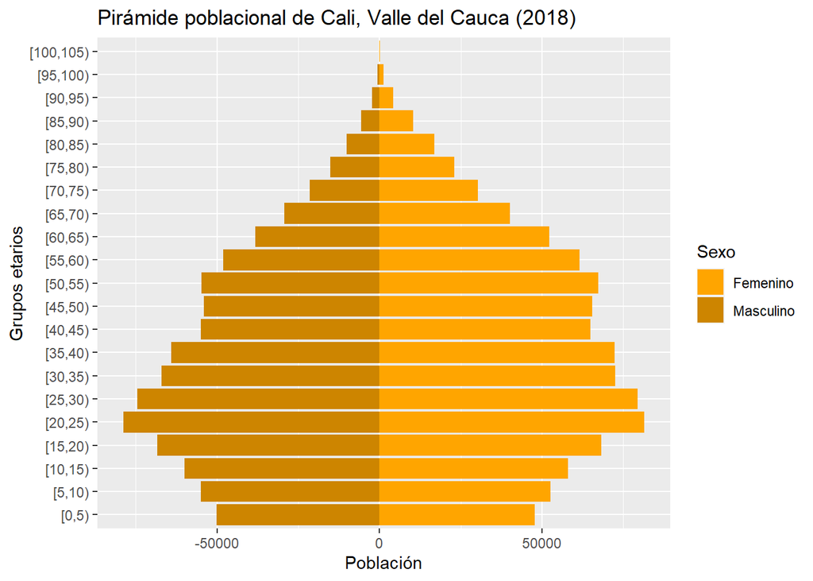

## Requerimientos de energía diarios promedio

Teniendo en consideración la estructura poblacional anterior —extraída del Censo del 2018— y la información sobre requerimientos de energía diarios —extraída de la resolución 003803 de 2016—, se deduce el promedio ponderado del requerimiento de energía para niños y jóvenes diferenciados según el sexo y los grupos etarios.

### Requerimientos diarios de energía promedio según grupos etarios (sexo masculino)

Requerimientos diarios de energía promedio para niños y jóvenes de sexo masculino

| Grupos etarios | Actividad ligera (kcal/día) | Actividad moderada (kcal/día) | Actividad vigorosa (kcal/día) |
| --- | --- | --- | --- |
| [1,4) | NaN | 1108.949 | NaN |
| [4,9) | 1450.783 | 1588.599 | 1951.175 |
| [9,14) | 2009.551 | 2365.406 | 2716.074 |
| [14,19) | 2747.859 | 3229.675 | 3718.094 |

### Requerimientos diarios de energía promedio según grupos etarios (sexo femenino)

Requerimientos diarios de energía promedio para niñas y jóvenes de sexo femenino

[output not shown]

# Peso y talla promedio para la población de Cali

En lo sucesivo, con base en los datos antropométricos suministrados por la Encuesta Nacional de Situación Nutricional (ENSIN) de 2015, se deduce el peso y talla promedio de la población de Cali según dos divisiones de grupos etarios: primero, las personas de entre 4 y 8 años, 9 y 13 años, 14 y 17 años, 18 y 29 años, 30 y 59 años, y $\geq 60$ años; segundo, las personas de entre 4 y 8 años, 9 y 13 años, 14 y 17 años, 18 y 30 años, 31 y 50 años, 51 y 70 años, y $\geq 70$ años. Los cálculos son contrastados con el caso del Valle del Cauca y el caso nacional[^1].

## Primera división de grupos etarios

Tabla 1: Peso y talla promedio (Cali, Valle del Cauca)

| Edad | Peso (masculino) | Talla (masculino) | Peso(femenino) | Talla(femenino) |
| --- | --- | --- | --- | --- |
| [18,30) | 65.19217 | 171.3325 | 55.10437 | 158.0432 |
| [30,60) | 65.48052 | 169.2292 | 55.60208 | 156.7896 |
| [60,Inf) | 63.88889 | 165.7333 | 55.38800 | 156.1120 |

Tabla 2: Peso y talla promedio (Valle del Cauca)

| Edad | Peso (masculino) | Talla (masculino) | Peso(femenino) | Talla(femenino) |
| --- | --- | --- | --- | --- |
| [18,30) | 63.07606 | 170.0972 | 55.44907 | 158.0068 |
| [30,60) | 64.18154 | 168.2308 | 55.17186 | 155.7397 |
| [60,Inf) | 62.74138 | 165.9552 | 53.32800 | 151.4400 |

Tabla 3: Peso y talla promedio (Colombia)

| Edad | Peso (masculino) | Talla (masculino) | Peso(femenino) | Talla(femenino) |
| --- | --- | --- | --- | --- |
| [18,30) | 62.96861 | 168.8277 | 54.50128 | 156.8686 |
| [30,60) | 63.31349 | 166.6092 | 54.87974 | 155.0208 |
| [60,Inf) | 60.97368 | 164.0214 | 53.04521 | 152.1337 |

## Segunda división de grupos etarios

Tabla 4: Peso y talla promedio (Cali, Valle del Cauca)

| Edad | Peso (masculino) | Talla (masculino) | Peso(femenino) | Talla(femenino) |
| --- | --- | --- | --- | --- |
| [18,31) | 65.27209 | 171.4837 | 55.24923 | 158.1913 |
| [31,51) | 65.79722 | 169.5796 | 55.94206 | 156.8722 |
| [51,70) | 64.18966 | 166.8259 | 54.71013 | 155.8873 |
| [70,Inf) | NaN | NaN | NaN | NaN |

Tabla 5: Peso y talla promedio (Valle del Cauca)

| Edad | Peso (masculino) | Talla (masculino) | Peso(femenino) | Talla(femenino) |
| --- | --- | --- | --- | --- |
| [18,31) | 63.22715 | 170.0556 | 55.53721 | 158.0349 |
| [31,51) | 64.71259 | 168.9811 | 55.64577 | 156.2415 |
| [51,70) | 62.36806 | 165.6778 | 53.31831 | 152.8028 |
| [70,Inf) | NaN | NaN | NaN | NaN |

Tabla 6: Peso y talla promedio (Colombia)

| Edad | Peso (masculino) | Talla (masculino) | Peso(femenino) | Talla(femenino) |
| --- | --- | --- | --- | --- |
| [18,31) | 62.99424 | 168.7499 | 54.54702 | 156.8399 |
| [31,51) | 63.76188 | 167.0562 | 55.20161 | 155.4078 |
| [51,70) | 61.70654 | 164.8408 | 53.54128 | 153.0633 |
| [70,Inf) | NaN | NaN | NaN | NaN |

# Actividad física según grupos etarios en Cali, Valle del Cauca

En virtud de la información suministrada por la ENSIN de 2015, se deduce la proporción de personas en Cali que satisfacen los requerimientos mínimos de actividad física a la semana. Un ejercicio análogo se presenta para el caso nacional. En lo sucesivo, se consideran dos divisiones de grupos etarios: primero, las personas de entre 4 y 8 años, 9 y 13 años, 14 y 17 años, 18 y 29 años, 30 y 59 años, y $\geq 60$ años; segundo, las personas de entre 4 y 8 años, 9 y 13 años, 14 y 17 años, 18 y 30 años, 31 y 50 años, 51 y 70 años, y $\geq 70$ años.

## Nivel de actividad física en Cali, Valle del Cauca

### Primera división de grupos etarios

Considérese los siguientes 12 grupos demográficos: personas de sexo masculino y femenino en los 6 grupos etarios (4 y 8 años, 9 y 13 años, 14 y 17 años, 18 y 29 años, 30 y 59 años, y $\geq 60$ años). La muestra de Cali corresponde a 786 personas (344 de sexo femenino y 442 de sexo masculino). El 51.36% de las personas de sexo masculino afirmaron que no cumplen los requerimientos mínimos de actividad física; mientras que el 68.6% de las personas de sexo femenino afirmaron que no cumplen los requerimientos mínimos.

Por hipótesis, si alguien satisface los requerimientos mínimos de actividad física a la semana, se considera que su nivel de actividad física es moderada; si no los satisface, su nivel de actividad física es ligera. La siguiente gráfica muestra los niveles de actividad física en la población de Cali según sexo y grupo etario:

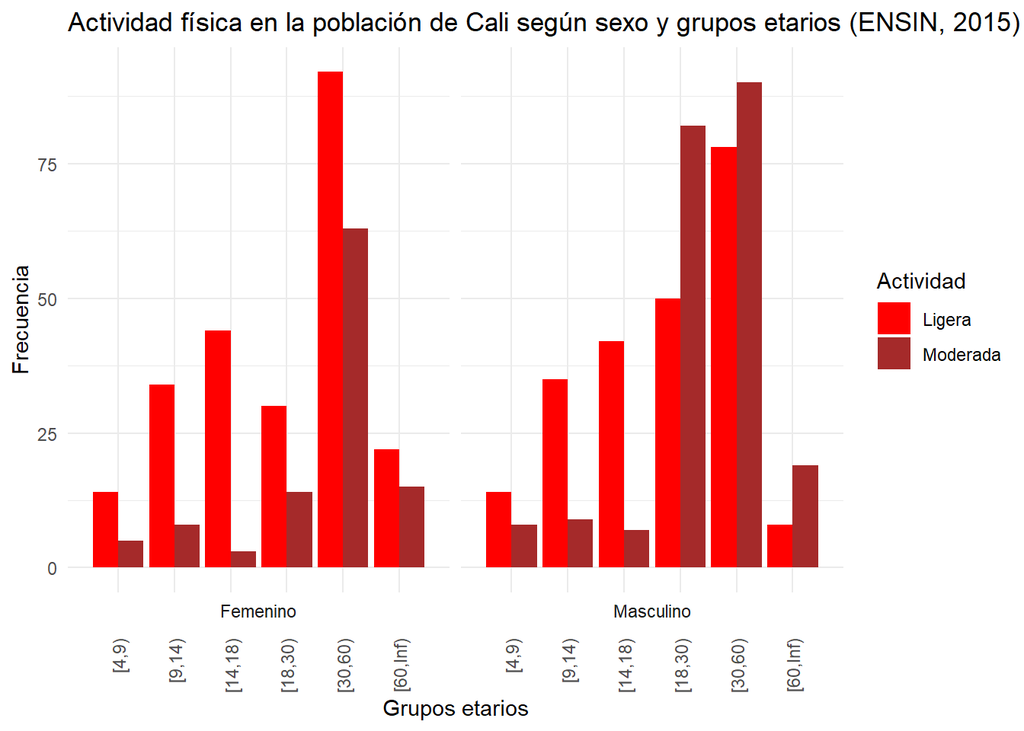

### Segunda división de grupos etarios

Un ejercicio idéntico se realiza considerando la siguiente división de grupos etarios: personas de sexo masculino y femenino en los 7 grupos etarios (4 y 8 años, 9 y 13 años, 14 y 17 años, 18 y 30 años, 31 y 50 años, 51 y 70 años, y $\geq 70$ años). Los resultados según sexo y grupos etarios para la población de Cali se presentan en la siguiente gráfica:

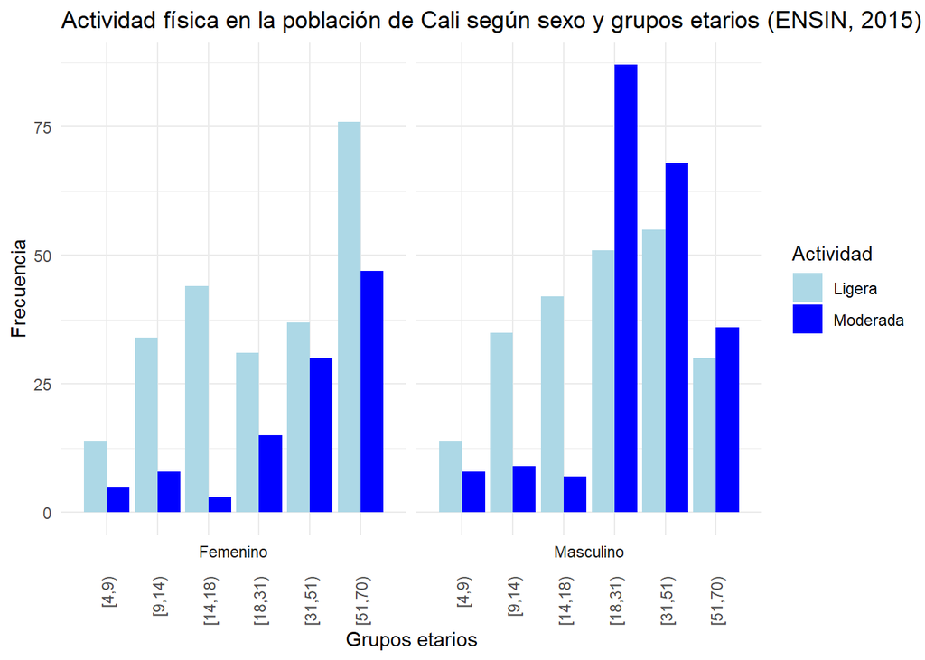

## Nivel de actividad física en Colombia

### Primera división de grupos etarios

Considérese los siguientes 12 grupos demográficos: personas de sexo masculino y femenino en los 6 grupos etarios (4 y 8 años, 9 y 13 años, 14 y 17 años, 18 y 29 años, 30 y 59 años, y $\geq 60$ años). La muestra nacional corresponde a 24517 personas (12160 de sexo masculino y 12357 de sexo femenino). El 52.82% de las personas de sexo masculino afirmaron que no cumplen los requerimientos mínimos de actividad física; mientras que el 68% de las personas de sexo femenino afirmaron que no cumplen los requerimientos mínimos (Nótese que, en comparación con la muestra de Cali, las proporciones no son significativamente distintas a nivel nacional). La siguiente gráfica muestra los niveles de actividad física en la población nacional según sexo y grupo etario:

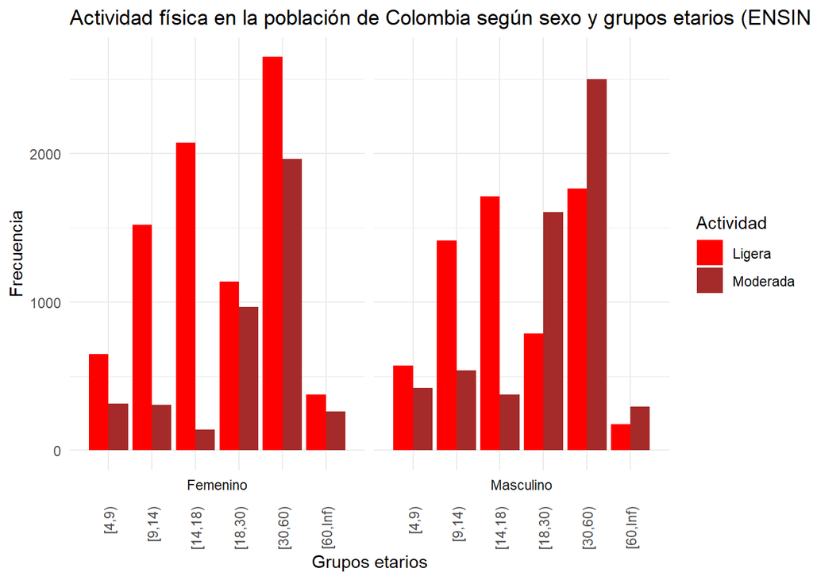

### Segunda división de grupos etarios

Considérese ahora la segunda división de grupos etarios: personas de sexo masculino y femenino en los 7 grupos etarios (4 y 8 años, 9 y 13 años, 14 y 17 años, 18 y 30 años, 31 y 50 años, 51 y 70 años, y $\geq 70$ años). Los resultados según sexo y grupos etarios para Colombia se presentan en la siguiente gráfica:

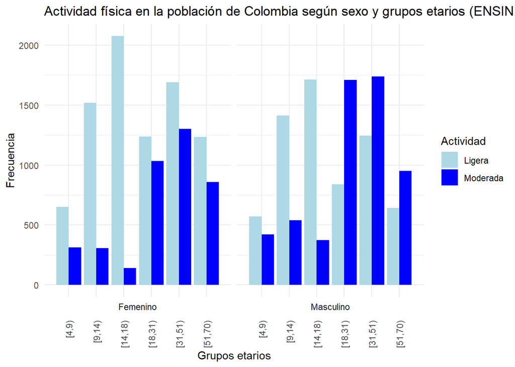

# Fuentes

1. DANE (2018). Censo Nacional de Población y Vivienda 2018. Información disponible en https://www.dane.gov.co/index.php/estadisticas-por-tema/demografia-y-poblacion/censo-nacional-de-poblacion-y-vivenda-2018
2. ICBF (2015). Encuesta Nacional de la Situación Nutricional (ENSIN). Información disponible en https://www.icbf.gov.co/bienestar/nutricion/encuesta-nacional-situacion-nutricional#ensin3

# Anexo

## Anexo 1: Peso y talla promedio para la población de Cali con base en los factores de expansión

De acuerdo con el documento metodológico de la ENSIN (2015), el factor básico de expansión corresponde al recíproco de la probabilidad final de selección. Recurriendo a los factores básicos de expansión, se presenta el promedio ponderado de la talla y el peso de la población de Cali según dos divisiones de grupos etarios. Un ejercicio análogo se presenta para el caso del Valle del Cauca y el caso nacional.

## Primera división de grupos etarios

Tabla A1: Peso y talla promedio ponderado (Cali, Valle del Cauca)

| Edad | Peso (masculino) | Talla (masculino) | Peso(femenino) | Talla(femenino) |
| --- | --- | --- | --- | --- |
| [18,30) | 65.72291 | 171.5257 | 54.86302 | 157.6712 |
| [30,60) | 65.42302 | 168.7785 | 55.75559 | 157.3327 |
| [60,Inf) | 63.29527 | 164.8925 | 56.27514 | 156.9170 |

Tabla 2: Peso y talla promedio ponderado (Valle del Cauca)

| Edad | Peso (masculino) | Talla (masculino) | Peso(femenino) | Talla(femenino) |
| --- | --- | --- | --- | --- |
| [18,30) | 62.83871 | 169.9483 | 54.67360 | 156.9624 |
| [30,60) | 64.56568 | 167.8398 | 55.87427 | 156.2325 |
| [60,Inf) | 65.41433 | 167.2374 | 53.98075 | 151.8265 |

Tabla 3: Peso y talla promedio ponderado (Colombia)

| Edad | Peso (masculino) | Talla (masculino) | Peso(femenino) | Talla(femenino) |
| --- | --- | --- | --- | --- |
| [18,30) | 63.16720 | 169.3012 | 54.65005 | 157.4073 |
| [30,60) | 63.90489 | 167.0147 | 55.46378 | 155.9469 |
| [60,Inf) | 61.88407 | 164.3015 | 53.69254 | 152.9160 |

## Segunda división de grupos etarios

Tabla A4: Peso y talla promedio ponderado (Cali, Valle del Cauca)

| Edad | Peso (masculino) | Talla (masculino) | Peso(femenino) | Talla(femenino) |
| --- | --- | --- | --- | --- |
| [18,31) | 65.74341 | 171.6007 | 55.07056 | 157.8032 |
| [31,51) | 65.65114 | 169.0720 | 55.83686 | 157.4033 |
| [51,70) | 64.29196 | 166.7094 | 55.38813 | 156.6158 |
| [70,Inf) | NaN | NaN | NaN | NaN |

Tabla A5: Peso y talla promedio ponderado (Valle del Cauca)

| Edad | Peso (masculino) | Talla (masculino) | Peso(femenino) | Talla(femenino) |
| --- | --- | --- | --- | --- |
| [18,31) | 63.11121 | 169.9367 | 54.90255 | 157.2759 |
| [31,51) | 64.50284 | 167.8791 | 56.41383 | 156.7524 |
| [51,70) | 64.59297 | 167.2008 | 53.50147 | 152.4528 |
| [70,Inf) | NaN | NaN | NaN | NaN |

Tabla A6: Peso y talla promedio ponderado (Colombia)

| Edad | Peso (masculino) | Talla (masculino) | Peso(femenino) | Talla(femenino) |
| --- | --- | --- | --- | --- |
| [18,31) | 63.19391 | 169.1976 | 54.73036 | 157.3907 |
| [31,51) | 64.48068 | 167.6126 | 55.64101 | 156.2406 |
| [51,70) | 62.08503 | 164.8776 | 54.47971 | 154.2523 |
| [70,Inf) | NaN | NaN | NaN | NaN |

[^1]: Para un ejercicio análogo empleando los factores de expansión de la ENSIN 2015, véase el **Anexo 1**